# Reproducible research course project 1

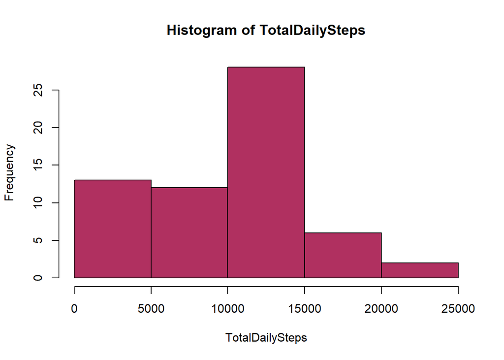

```r
TotalDailySteps<-with(Ex, tapply(steps, date, sum, na.rm=TRUE))
hist(TotalDailySteps, col = "maroon")
```

The next step is to report the mean and median of total number of steps taken each day. This is a simple and straight forward task

```r
meanStep<-round(mean(TotalDailySteps), 2)
medianStep<-round(median(TotalDailySteps), 2)
```

so the meanstep is 9354.23 and medianStep is 10395

# What is the average daily activity pattern?

```r
intervalSteps<-with(Ex, tapply(steps, interval, mean, na.rm=TRUE))
```

Now, we can plot the mean step value for each interval. Again, ‘base plotting system’ is more the sufficient for this step.

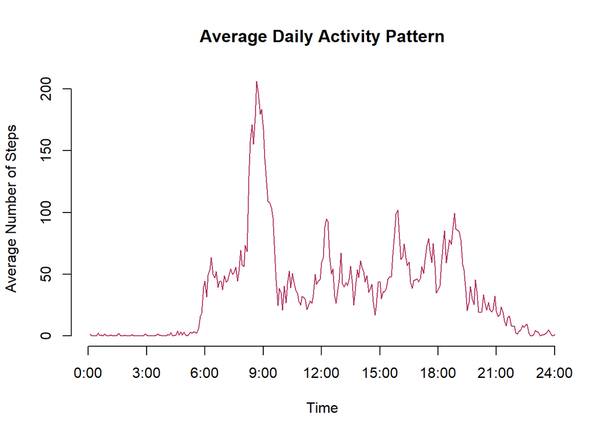

```r
plot(intervalSteps,axes = F, type="l", col="maroon", xlab="Time", ylab="Average Number of Steps", main="Average Daily Activity Pattern")
axis(1,at=c(0, 36, 72, 108, 144, 180, 216, 252, 288), label = c("0:00", "3:00","6:00", "9:00", "12:00","15:00","18:00","21:00","24:00"))
axis(2)
```

We also have been asked about the interval with maximum average steps taken within. We can calculate it as follow:

```r
intervalSteps[which.max(intervalSteps)]
```

```
##      835
## 206.1698
```

# Imputing missing values

First, I want to report the number of missing values.

```r
NAcount<-sum(is.na(Ex$steps))
NAcount
```

```
## [1] 2304
```

In this data frame, there are 2304 rows with missing value for ‘Steps’ variable.

# For imputing missing values, I use the very nice “MICE” package.

```r
library(mice)
imputedValues<-mice(Ex)
```

Now we have imputed values and can reconstruct the new database:

```r
imputedEx<-complete(imputedValues)
```

Preprocessing of new dataframe:

```r
imputedEx$date<-as.Date(imputedEx$date)
```

Calculating total daily steps:

```r
TotalDailySteps_Ex<-with(imputedEx, tapply(steps, date, sum, na.rm=TRUE))
```

Making the histograms:

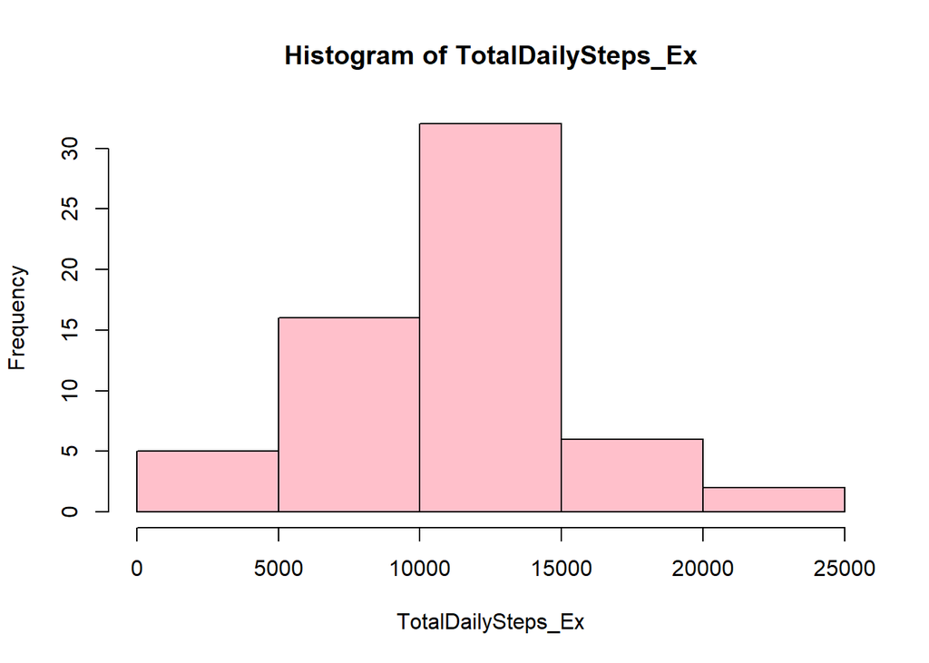

```r
hist(TotalDailySteps_Ex, col = "pink")
```

Calculating the central values:

```r
meanStep_Ex<-round(mean(TotalDailySteps_Ex), 2)
medianStep_Ex<-round(median(TotalDailySteps_Ex), 2)
```

Calculating the resulted change in central values:

```r
meanDiff<- meanStep - meanStep_Ex
medianDiff<- medianStep - medianStep_Ex
```

## Are there differences in activity patterns between weekdays and weekends?

In the last step, we want to compare the difference between activity on weekdays and weekends.

```r
imputedEx$weekdays<-weekdays(imputedEx$date)
imputedEx$dayType<-ifelse(imputedEx$weekdays%in%c("Saturday", "Sunday"), "Weekend", "Weekday")
```

Now, we can calculate average steps in each interval based on type of weekday:

```r
intervalDaySteps<-aggregate(steps~interval+dayType, data = imputedEx, mean)
```

For plotting data in two panels, I use the ggplot2 system:

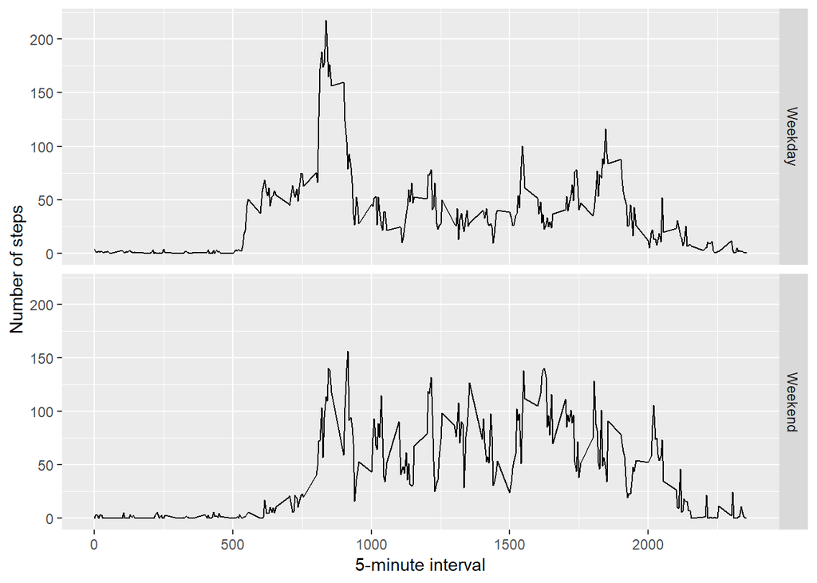

```r
library(ggplot2)
g1<-ggplot(intervalDaySteps, aes(interval, steps))
g1 + geom_line() +
        facet_grid(dayType ~ .) +
        xlab("5-minute interval") +
        ylab("Number of steps")
```

The end!